# Wrangling-Session2.1-Assignment

Lauren

2023-11-21

```r
library(tidyverse)
library(dslabs)
```

Question 11: Examine the built-in dataset co2. This dataset comes with base R, not dslabs - just type co2 to access the dataset. Is co2 tidy? Why or why not?

Question 12: Define the co2_wide object & tidy format.

```r
data(co2)
str(co2)
```

```
##  Time-Series [1:468] from 1959 to 1998: 315 316 316 318 318 ...
```

```r
co2_wide <- data.frame(matrix(co2, ncol = 12, byrow = TRUE)) %>%
  setNames(1:12) %>%
  mutate(year = as.character(1959:1997))
str(co2_wide)
```

```
## 'data.frame':    39 obs. of  13 variables:
##  $ 1   : num  315 316 317 318 319 ...
##  $ 2   : num  316 317 318 318 319 ...
##  $ 3   : num  316 317 318 320 320 ...
##  $ 4   : num  318 319 319 320 321 ...
##  $ 5   : num  318 320 320 321 322 ...
##  $ 6   : num  318 319 320 320 321 ...
##  $ 7   : num  316 318 318 319 320 ...
##  $ 8   : num  315 316 317 317 318 ...
##  $ 9   : num  314 314 315 316 316 ...
##  $ 10  : num  313 314 315 315 316 ...
##  $ 11  : num  315 315 316 317 317 ...
##  $ 12  : num  315 316 317 318 318 ...
##  $ year: chr  "1959" "1960" "1961" "1962" ...
```

```r
co2_tidy <- co2_wide %>% pivot_longer(-year, names_to = "month", values_to = "co2")
co2_tidy
```

```
## # A tibble: 468 × 3
##    year  month   co2
##    <chr> <chr> <dbl>
##  1 1959  1      315.
##  2 1959  2      316.
##  3 1959  3      316.
##  4 1959  4      318.
##  5 1959  5      318.
##  6 1959  6      318
##  7 1959  7      316.
##  8 1959  8      315.
##  9 1959  9      314.
## 10 1959  10     313.
## # ℹ 458 more rows
```

Question 13: Use co2_tidy to plot CO2 versus month with a different curve for each year:

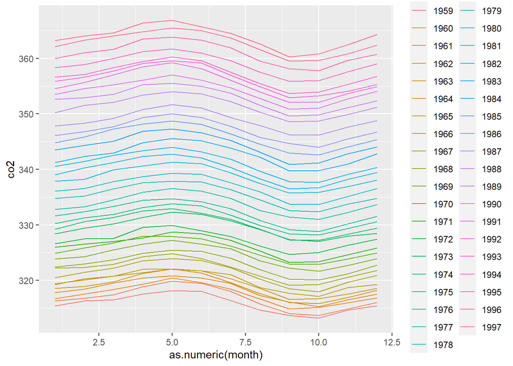

```r
co2_tidy %>% ggplot(aes(as.numeric(month), co2, color = year)) + geom_line()
```

Question 14: Load the admissions dataset from dslabs, which contains college admission information for men and women across six majors, and remove the applicants percentage column. Which command could help you to wrangle the data into the desired format?

```r
library(dslabs)
data(admissions)
dat4 <- admissions %>% select(-applicants)
dat4
```

```
##    major gender admitted
## 1      A    men       62
## 2      B    men       63
## 3      C    men       37
## 4      D    men       33
## 5      E    men       28
## 6      F    men        6
## 7      A  women       82
## 8      B  women       68
## 9      C  women       34
## 10     D  women       35
## 11     E  women       24
## 12     F  women        7
```

```r
dat4_tidy <- pivot_wider(dat4, names_from = gender, values_from = admitted)
dat4_tidy
```

```
## # A tibble: 6 × 3
##   major   men women
##   <chr> <dbl> <dbl>
## 1 A        62    82
## 2 B        63    68
## 3 C        37    34
## 4 D        33    35
## 5 E        28    24
## 6 F         6     7
```

```r
tmp <- admissions %>%
  pivot_longer(cols = c(admitted, applicants), names_to = "key", values_to = "value")
tmp
```

```
## # A tibble: 24 × 4
##    major gender key        value
##    <chr> <chr>  <chr>      <dbl>
##  1 A     men    admitted      62
##  2 A     men    applicants   825
##  3 B     men    admitted      63
##  4 B     men    applicants   560
##  5 C     men    admitted      37
##  6 C     men    applicants   325
##  7 D     men    admitted      33
##  8 D     men    applicants   417
##  9 E     men    admitted      28
## 10 E     men    applicants   191
## # ℹ 14 more rows
```

```r
tmp2 <- tmp %>% unite(column_name, c(key, gender))
tmp2
```

```
## # A tibble: 24 × 3
##    major column_name    value
##    <chr> <chr>          <dbl>
##  1 A     admitted_men      62
##  2 A     applicants_men   825
##  3 B     admitted_men      63
##  4 B     applicants_men   560
##  5 C     admitted_men      37
##  6 C     applicants_men   325
##  7 D     admitted_men      33
##  8 D     applicants_men   417
##  9 E     admitted_men      28
## 10 E     applicants_men   191
## # ℹ 14 more rows
```